# Analisando a qualidade de projetos de desenvolvimento de software

Veruska Santos

16 de abril de 2018

O desenvolvimento de software é um processo caracterizado pelo planejamento das atividades, desenvolvimento do produto, verificação da qualidade e adaptações. Este é um ciclo que, não necessariamente, obedece esta ordem. Há diversos estudos que analizam este processo, afim de entender relações, otimizar prazos, melhorar estratégias de desenvolvimento e diversas outras coisas. Assim, dado um conjunto de projetos de desenvolvimento de software, disponíveis no TravisTrorrent¹, decidimos analisar a relação entre algumas variáveis, com o objetivo de identificar possíveis relações entre a qualidade de código e projetos de diferentes linguagens. Dessa forma, surgiu a seguinte Questão de Pesquisa (QP):

**QP: Existe diferença significativa entre a qualidade de código de projetos de diferentes linguagens?**

Para responder tal pergunta, utilizamos a linguagem R e o RStudio que facilitam a análise dos dados.

### Entendendo os dados

A partir de uma amostra de 1270 projetos, analisaremos as seguintes variáveis:

- **lang:** representa a linguagem dominante de cada projeto, com valores “java”, “ruby” e “javascript”. Dados com lang = “javascript” foram desconsiderados desta análise, pois, possivelmente são erros, já que não eram objeto de coleta, segundo a descrição de quem os coletou. Os valores “ruby” são a maioria na base de dados.
- **build_sucess_prop:** representa a proporção de builds que deram sucesso, de cada projeto. Os valores desta variável variam entre [0.0, 1.0], porém a concentração dos valores está entre [0.5, 1.0].
- **tests_per_kloc:** representa a quantidade de testes para cada mil linhas de código. Os valores desta variável variam entre [0.0, 6192.3077], porém a concentração dos valores está entre [0.0, 815.7895].
- **test_density:** representa a densidade de testes do projeto. Os valores desta variável variam entre [0.0, 2366.6667], sendo o valor máximo um outlier.

### Pré-processamento

Importando biblioteca do R a ser usada para ler os dados e manipulá-los.

```r
library(tidyverse)
library(ggplot2)
library(grid)
library(dplyr)
```

Carregando os dados, já processados pelo prof. Nazareno, que serão analisados.

```r
projetos = read_csv(here::here("data/projetos.csv"))
```

Para analisar os dados, excluímos os projetos cuja linguagem principal é Javascript, porque não possui uma quantidade significativa em relação aos projetos Java e Ruby, na amostra disponibilizada.

```r
projetos = projetos %>%
    filter(lang != "javascript")
```

### Análise: Existe diferença significativa entre a qualidade de código de projetos de diferentes linguagens?

A partir dos dados disponibilizados no travis, gostaríamos de verificar qual a linguagem de programação que apresenta projetos com índices de melhor qualidade de código, como quantidade de testes, densidade e proporção de builds de sucesso. Assim, supõe-se que, pela linguagem Java ser mais popular, a qualidade de projetos desenvolvidos nesta linguagem também seja melhor.

#### Seção 1

Abaixo seguem alguns gráficos que mostram a distribuição das variáveis **lang**, **tests_per_kloc**, **test_density** e **build_success_prop**, para identificar possíveis relações que ajudem a responder à QP.

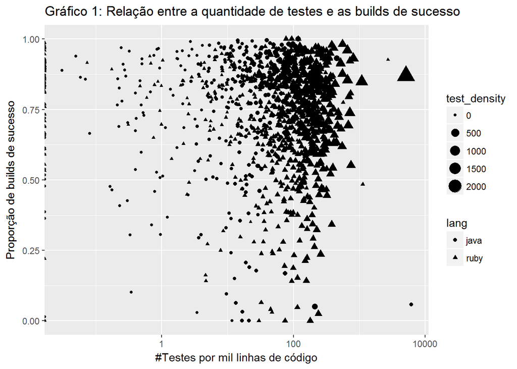

```r
projetos %>%
    ggplot(aes(x = tests_per_kloc, y = build_success_prop, shape = lang, size = test_density)) +
    geom_point() +
    scale_x_log10() +
    ggtitle("Gráfico 1: Relação entre a quantidade de testes e as builds de sucesso") +
    xlab("#Testes por mil linhas de código") +
    ylab("Proporção de builds de sucesso")
```

O Gráfico 1, acima, nos dá indícios de que, os projetos na linguagem Ruby, representados por triângulos, possuem mais densidade de testes do que os projetos na linguagem Java, pois, identificamos os triângulos em destaque no gráfico, além disso, nos projetos de ambas as linguagens, a proporção de builds de sucesso é, em geral, elevada, porque estão concentrados na parte superior da visualização. Entretanto, é difícil identificar de qual linguagem os projetos possuem maior quantidade de testes ou se não há diferença.

Ainda sobre as mesmas variáveis, criamos outra visualização, semelhante à anterior.

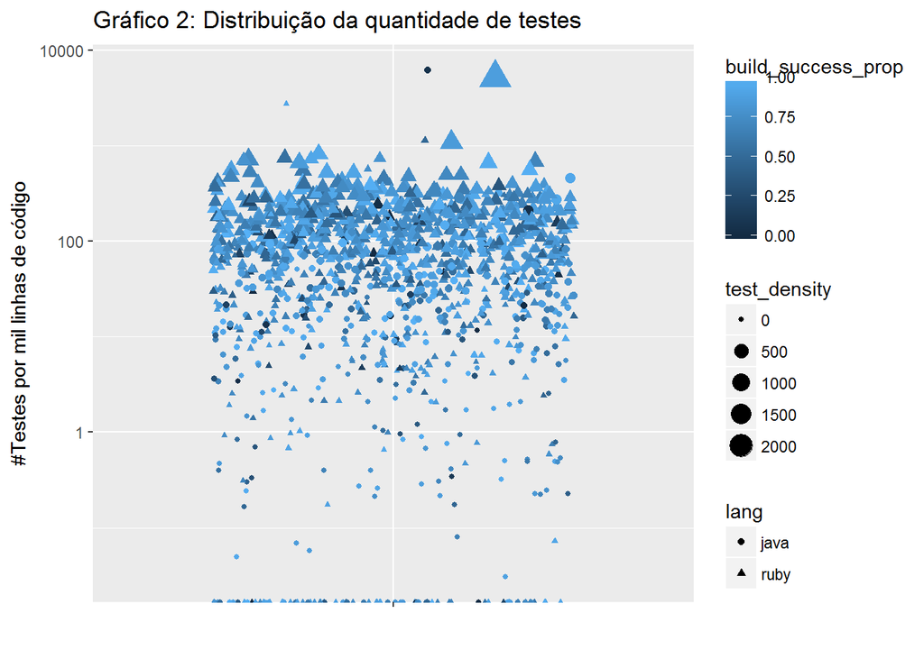

```r
projetos %>%
    ggplot(aes(x = "", y = tests_per_kloc, shape = lang, size = test_density, color = build_success_prop)) +
    geom_jitter(width = .3) +
    scale_y_log10() +
    ggtitle("Gráfico 2: Distribuição da quantidade de testes") +
    xlab("") +
    ylab("#Testes por mil linhas de código")
```

O Gráfico 2, acima, confirma as mesmas respostas encontradas no Gráfico 1 e, ainda, nos dá indícios de que os projetos na linguagem Ruby, representados por triângulos, possuem mais testes.

Outra forma de observar a relação existente entre qualidade de código e linguagem de programação é através do gráfico de linhas que sumariza os dados e exibe a relação existente através de uma linha, que, neste caso, é crescente, mas não necessariamente linear, como exibido abaixo.

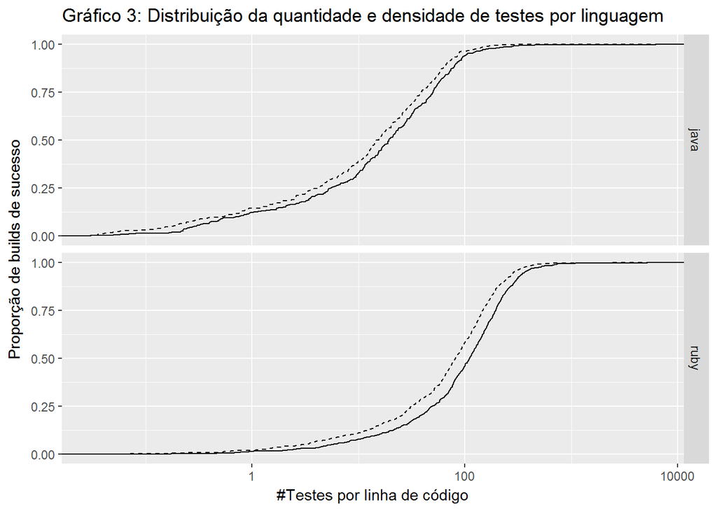

```r
projetos %>%
    ggplot() +
    stat_ecdf(aes(x = tests_per_kloc, y = build_success_prop)) +
    stat_ecdf(aes(x = test_density, y = build_success_prop), linetype = "dashed") +
    scale_x_log10() +
    facet_grid(lang ~ .) +
    ggtitle("Gráfico 3: Distribuição da quantidade e densidade de testes por linguagem") +
    xlab("#Testes por linha de código") +
    ylab("Proporção de builds de sucesso")
```

#### Seção 2

Assim, nenhum dos gráficos exibidos na sessão 1 acima respondeu claramente à QP, mas, com alguns ajustes, eles foram melhorados, facilitando a interpretação, como você pode observar os resultados abaixo.

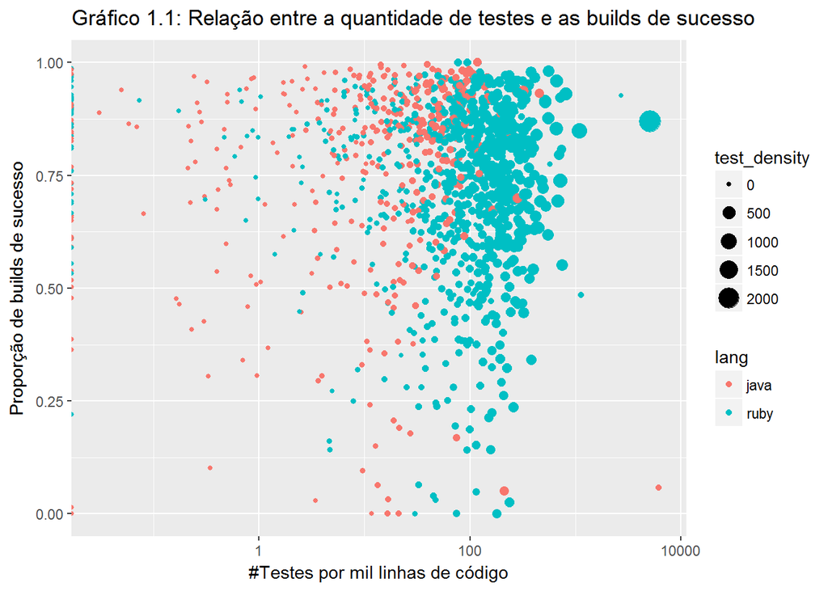

```r
projetos %>%
    ggplot(aes(x = tests_per_kloc, y = build_success_prop, color = lang, size = test_density)) +
    geom_point() +
    scale_x_log10() +
    ggtitle("Gráfico 1.1: Relação entre a quantidade de testes e as builds de sucesso") +
    xlab("#Testes por mil linhas de código") +
    ylab("Proporção de builds de sucesso")
```

O Gráfico 1.1, acima, diferente do Gráfico 1, utiliza as cores ao invés de formas geométricas, para identificar as linguagens de programação e, agora, facilmente, identificamos também que os projetos da linguagem Ruby possuem mais testes, além das mesmas constatações descritas na análise do Gráfico 1.

O Gráfico 2.1, abaixo, diferente do Gráfico 2, separa os projetos de cada linguagem em posições, esquerda ou direita, ao invés de usar formas geométricas. Assim, é possível afirmar com mais clareza que os projetos na linguagem Ruby possuem mais testes, porque estão concentrados mais acima dos projetos na linguagem Java.

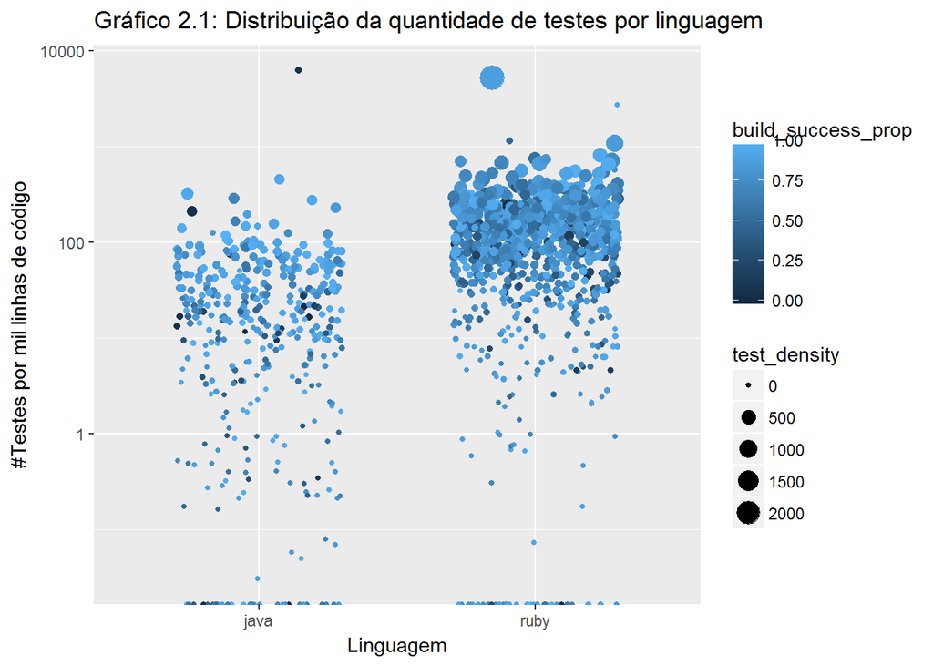

```r
projetos %>%
    ggplot(aes(x = lang, y = tests_per_kloc, size = test_density, color = build_success_prop)) +
    geom_jitter(width = .3) +
    scale_y_log10() +
    ggtitle("Gráfico 2.1: Distribuição da quantidade de testes por linguagem") +
    xlab("Linguagem") +
    ylab("#Testes por mil linhas de código")
```

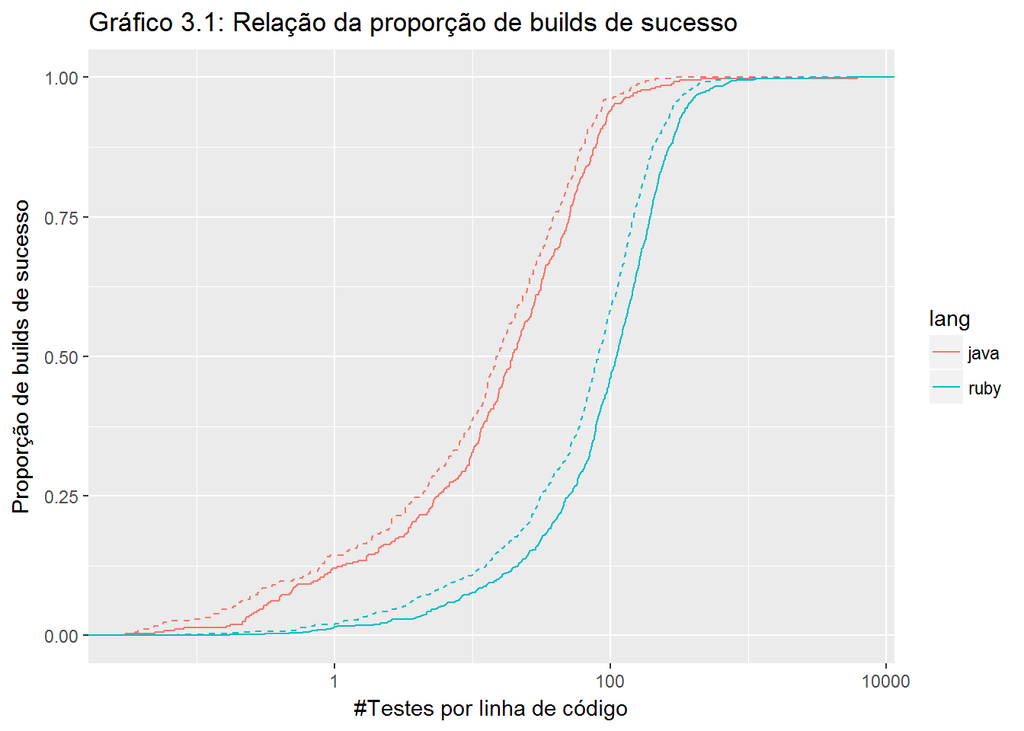

```r
projetos %>%
    ggplot() +
    stat_ecdf(aes(x = tests_per_kloc, y = build_success_prop, color = lang)) +
    stat_ecdf(aes(x = test_density, y = build_success_prop, color = lang), linetype = "dashed") +
    scale_x_log10() +
    ggtitle("Gráfico 3.1: Relação da proporção de builds de sucesso") +
    xlab("#Testes por linha de código") +
    ylab("Proporção de builds de sucesso")
```

### Conclusão

¹ https://travistorrent.testroots.org